# ENV 790.30 - Time Series Analysis for Energy Data | Spring 2024

Assignment 2 - Due date 02/25/24

Yilun Zhu

## Submission Instructions

You should open the .rmd file corresponding to this assignment on RStudio. The file is available on our class repository on Github.

Once you have the file open on your local machine the first thing you will do is rename the file such that it includes your first and last name (e.g., “LuanaLima_TSA_A02_Sp24.Rmd”). Then change “Student Name” on line 4 with your name.

Then you will start working through the assignment by **creating code and output** that answer each question. Be sure to use this assignment document. Your report should contain the answer to each question and any plots/tables you obtained (when applicable).

When you have completed the assignment, **Knit** the text and code into a single PDF file. Submit this pdf using Sakai.

## R packages

R packages needed for this assignment:“forecast”,“tseries”, and “dplyr”. Install these packages, if you haven’t done yet. Do not forget to load them before running your script, since they are NOT default packages.\

```r
#Load/install required package here
library(forecast)
library(tseries)
library(dplyr)
```

```r
library(ggplot2)
```

## Data set information

Consider the data provided in the spreadsheet “Table_10.1_Renewable_Energy_Production_and_Consumption_by_Source.xlsx” on our **Data** folder. The data comes from the US Energy Information and Administration and corresponds to the December 2023 Monthly Energy Review. The spreadsheet is ready to be used. You will also find a $.csv$ version of the data “Table_10.1_Renewable_Energy_Production_and_Consumption_by_Source-Edit.csv”. You may use the function $read.table()$ to import the $.csv$ data in R. Or refer to the file “M2_ImportingData_CSV_XLSX.Rmd” in our Lessons folder for functions that are better suited for importing the $.xlsx$.

```r
#Importing data set
Renew_eng <- read.table(file = "./Table_10.1_Renewable_Energy_Production_and_Consumption_by_Source.csv", header=TRUE,dec = ".",sep=",",stringsAsFactors = TRUE)
```

## Question 1

You will work only with the following columns: Total Biomass Energy Production, Total Renewable Energy Production, Hydroelectric Power Consumption. Create a data frame structure with these three time series only. Use the command head() to verify your data.

```r
V_Renew_eng <- Renew_eng[,4:6]
Date <- Renew_eng[,1]
Renew_eng <- cbind(Date, V_Renew_eng)
```

## Question 2

Transform your data frame in a time series object and specify the starting point and frequency of the time series using the function ts().

```r
ts_Renew_eng <- ts(Renew_eng[,2:4], start = c(1973,1), frequency = 12)
```

## Question 3

Compute mean and standard deviation for these three series.

```r
meanTBEP <- mean(ts_Renew_eng[,1])
#[1] 279.8046 "Total.Biomass.Energy.Production"
meanTREP <- mean(ts_Renew_eng[,2])
#[1] 395.7213 "Total.Renewable.Energy.Production"
meanHPC <- mean(ts_Renew_eng[,3])
#[1] 79.73071 "Hydroelectric.Power.Consumption"
sd(ts_Renew_eng[,1])
```

```
## [1] 92.66504
```

```r
#[1] 92.66504 "Total.Biomass.Energy.Production"
sd(ts_Renew_eng[,2])
```

```
## [1] 137.7952
```

```r
#[1] 137.7952 "Total.Renewable.Energy.Production"
sd(ts_Renew_eng[,3])
```

```
## [1] 14.14734
```

```r
#[1] 14.14734 "Hydroelectric.Power.Consumption"
```

## Question 4

Display and interpret the time series plot for each of these variables. Try to make your plot as informative as possible by writing titles, labels, etc. For each plot add a horizontal line at the mean of each series in a different color.

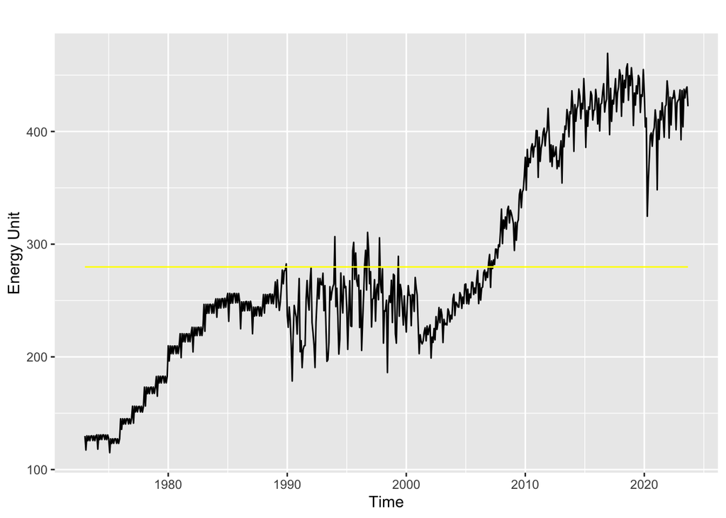

```r
GraghTBEP <- autoplot(ts_Renew_eng[,1], ylab = "Energy Unit")
GraghTREP <- autoplot(ts_Renew_eng[,2], ylab = "Energy Unit")
GraghHPC <- autoplot(ts_Renew_eng[,3], ylab = "Energy Unit")
GraphTBEP <- GraghTBEP + geom_line(aes(y=meanTBEP), color="yellow")
GraphTREP <- GraghTREP + geom_line(aes(y=meanTREP), color = "purple")
GraphHPC <- GraghHPC + geom_line(aes(y=meanHPC), color = "red")
GraphTBEP
```

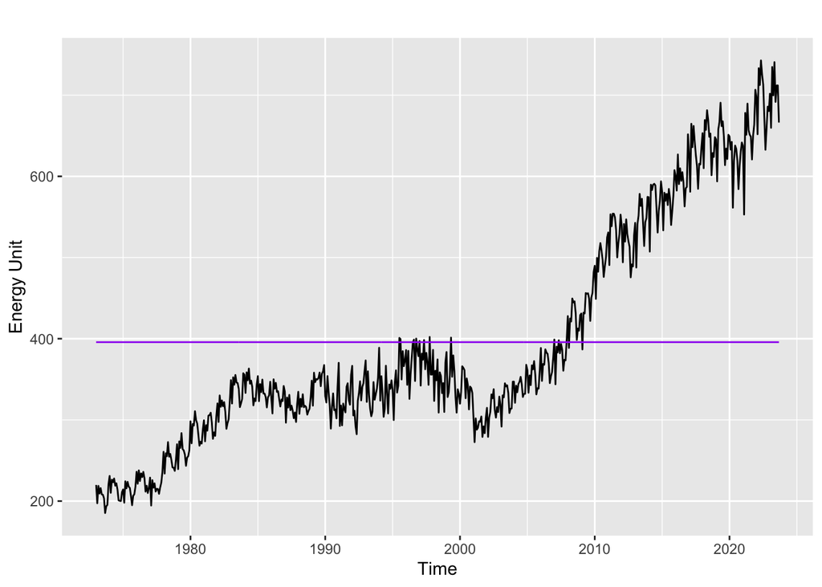

```r
GraphTREP
```

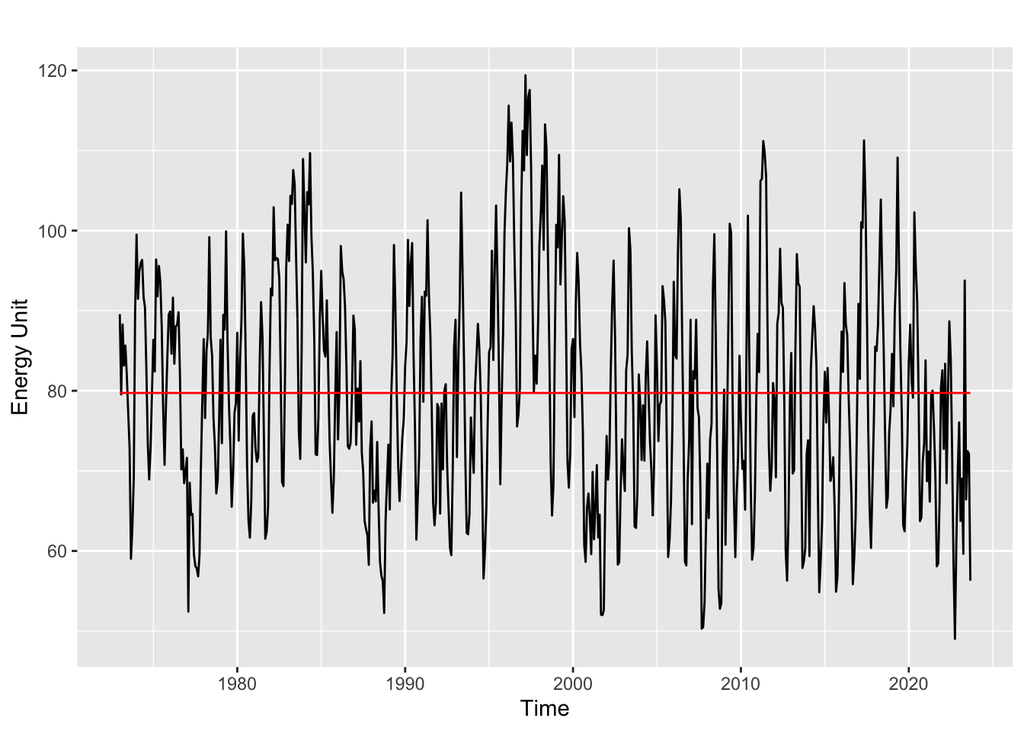

```r
GraphHPC
```

## Question 5

Compute the correlation between these three series. Are they significantly correlated? Explain your answer.

```r
cor(Renew_eng$Total.Biomass.Energy.Production, Renew_eng$Total.Renewable.Energy.Production)
```

```
## [1] 0.9707462
```

```r
#[1] 0.9707462 cor of TBEP and TREP
cor(Renew_eng$Total.Renewable.Energy.Production, Renew_eng$Hydroelectric.Power.Consumption)
```

```
## [1] -0.001768629
```

```r
#[1] -0.001768629 cor of TREP and HPC
cor(Renew_eng$Total.Biomass.Energy.Production, Renew_eng$Hydroelectric.Power.Consumption)
```

```
## [1] -0.09656318
```

```r
#[1] -0.09656318  cor of TBEP and HPC

#Answer：The outcome shows Total Biomass Energy Production(TBEP) has strong positive correlation with Total Renewable Energy Production(TREP). Because Biomass energy is a type of Renewable energy so it is likely also accounted in TREP.
```

## Question 6

Compute the autocorrelation function from lag 1 up to lag 40 for these three variables. What can you say about these plots? Do the three of them have the same behavior?

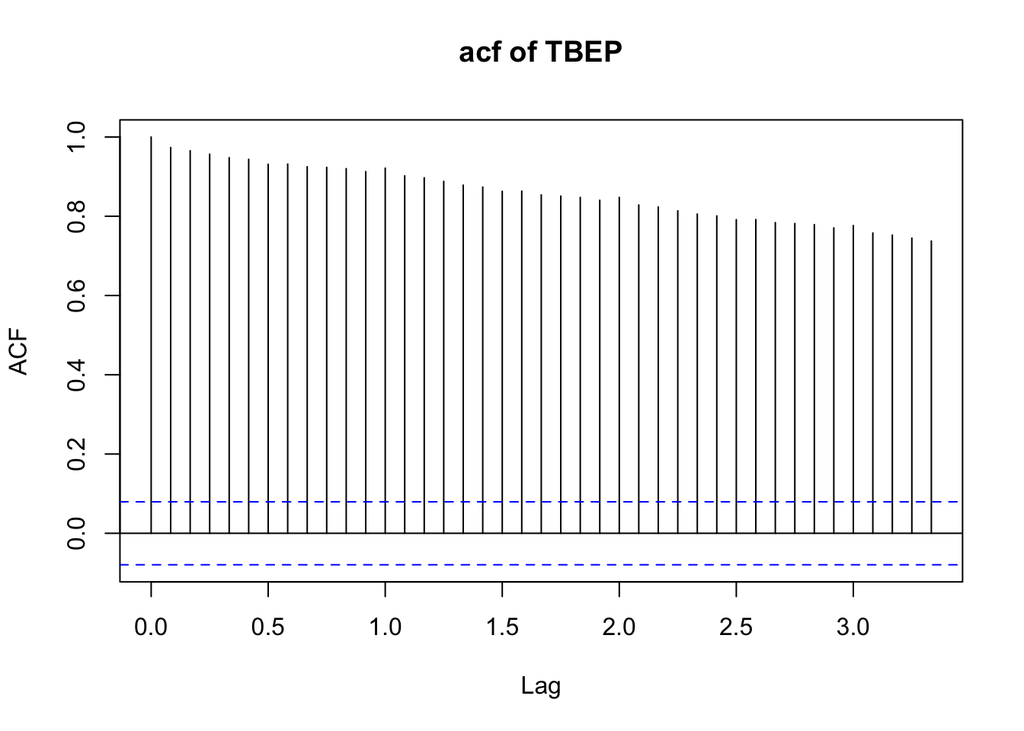

```r
TBEP_acf <- acf(ts_Renew_eng[,1], lag.max = 40,main = "acf of TBEP")
```

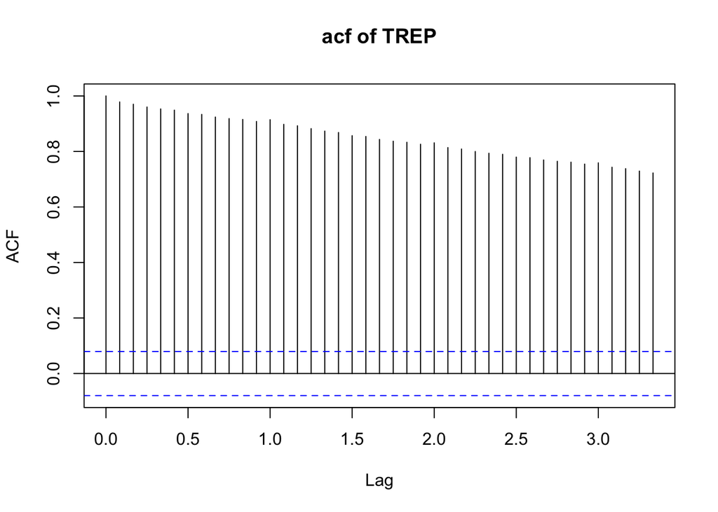

```r
TREP_acf <- acf(ts_Renew_eng[,2], lag.max = 40,main = "acf of TREP")
```

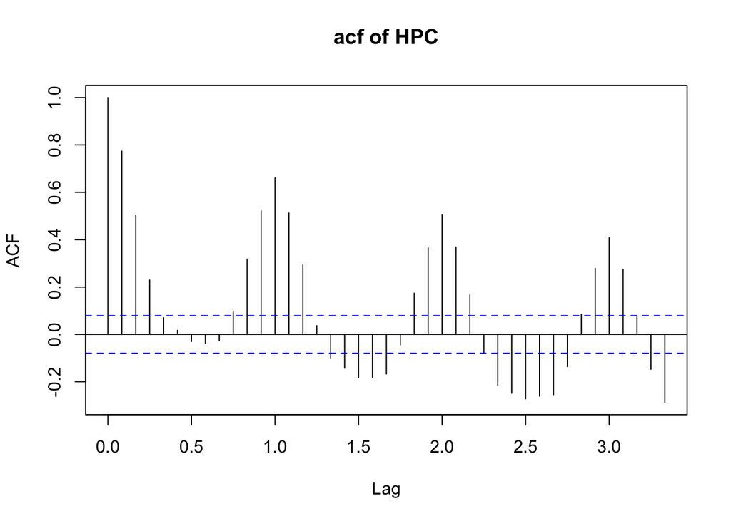

```r
HPC_acf <- acf(ts_Renew_eng[,3], lag.max = 40,main = "acf of HPC")
```

```r
#Answer: About Biomass energy and Renewable energy, they show similar autocorrelation and the reason i think is the same with their strong correlation. One feature for both is all autocorrelation is positive and has strong significance. About Hydropower, it has a different plot and shows a seasonal trend in acf, a cycle of 12/13 lags from a summit to bottom.
```

## Question 7

Compute the partial autocorrelation function from lag 1 to lag 40 for these three variables. How these plots differ from the ones in Q6?

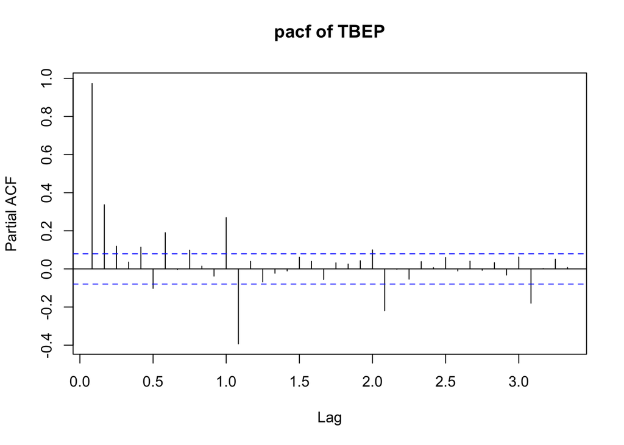

```r
TBEP_pacf <- pacf(ts_Renew_eng[,1], lag.max = 40, main = "pacf of TBEP")
```

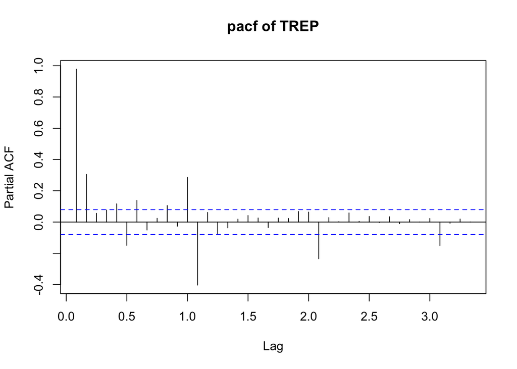

```r
TREP_pacf <- pacf(ts_Renew_eng[,2], lag.max = 40, main = "pacf of TREP")
```

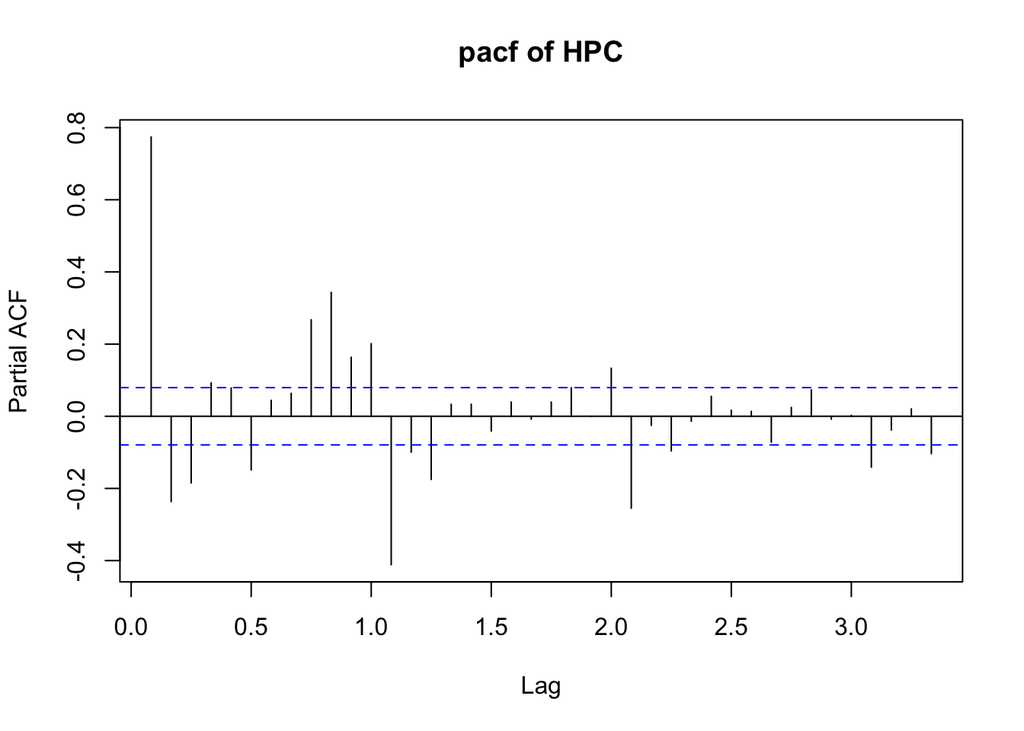

```r
HPC_pacf <- pacf(ts_Renew_eng[,3], lag.max = 40, main = "pacf of HPC")
```

```r
#Answer: Three plots show great difference with the graph in Q6, and are quite similar with each other. The significant feature is except the lag1, the rest are all lower than 0.5 even 0.4.
```